# Project ROJAK: Research On Judicious Amalgamation of Knowledge

This webpage is designed as a companion reading for our actual paper :)

## **Table of Contents for :**

- Section 1: Python Libraries
- Section 2: Understanding the WordNet Knowledge Graph
  - What are synsets?
  - Comparing normal word vs hybridised embeddings
- Section 3: Application of ROJAK Embeddings
  - Understanding our dataset
  - Model architecture
  - Codebase for the normal baseline model
  - Codebase for our ROJAK model

# Section 1: Importing relevant Python Libraries and data

```python
import pickle
import pandas as pd
import json
from tqdm import tqdm
from PIL import Image
import os
import sys
import numpy as np
import nltk
# nltk.download('wordnet')    # if you do not have WordNet downloaded on NLTK
from nltk.corpus import wordnet as wn
import tensorflow as tf
import cv2
import matplotlib.pyplot as plt
import random

from tensorflow.keras.preprocessing.text import Tokenizer
from tensorflow.keras.preprocessing.sequence import pad_sequences
from tensorflow.keras.models import Sequential, Model
from tensorflow.keras.layers import InputLayer, Conv2D, BatchNormalization, MaxPooling2D, Flatten, Embedding, \
Concatenate, Conv1D, MaxPooling1D, Multiply, Dense, Reshape, Dropout, Multiply
from tensorflow.keras.optimizers import Adam
from tensorflow.keras.utils import plot_model
from sklearn.model_selection import train_test_split, KFold
from sklearn.preprocessing import LabelBinarizer
from collections import Counter
```

# Section 2: Understanding the WordNet Knowledge Graph!

### What are synsets, or more intuitively, concepts in the knowledge graph?

We first seek to understand the idea of a "concept identifier", as we have described in Section 2.3 of our paper. We note that large-scale knowledge graphs tend to encompass entities as "concepts", or more formally known as synsets! We can use NLTK's WordNet API, and see for ourselves what a synset of the "dog" entity is! We use `definition` on the synset of interest, to see the unique meaning of that particular concept. We note that an entity can have multiple meanings (i.e polysemy), and these different meanings are represented using different numbers in the format <`lemma.POS_tag.concept_number`>. We can see 2 meanings for the specified "dog" entity.

```python
print(f'One meaning of the dog entity could be: \n{wn.synset("dog.n.01").definition()}')
```

```
One meaning of the dog entity could be:
a member of the genus Canis (probably descended from the common wolf) that has been domesticated by man since prehistoric times; occurs in many breeds
```

```python
print(f'Another meaning of the same dog entity could be \n{wn.synset("dog.n.02").definition()}')
```

```
Another meaning of the same dog entity could be
a dull unattractive unpleasant girl or woman
```

It is interesting to note how expressive concepts could be for a single entity, and we hope to use such concept identifiers to enrich our entity representations!

### Comparing normal word vs hybridised embeddings

We first look at trained Swivel word embeddings, and we are interested to look at the top k-neighbors for the entity "conference", based on cosine similarity measures. As discussed in Section 2.3 of our paper, we see that the neighbors are not very meaningful, and we would hope to get more semantically meaningful neighbors for our entity of interest.

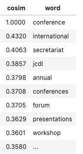

We compare the Swivel word embeddings, to a pretrained set of hybridised embeddings on the UMBC English corpus. We have provided the serialized embeddings as **vecsi_wn_umbc.pickle**. Feel free to load the pickled embeddings with the following command:

```python
with open('vecsi_wn_umbc.pickle', 'rb') as handle:
    embeddings = pickle.load(handle)
embeddings.top_k_neighbors('wn31_conference.n.01')
```

We should get a result, which looks like the following output!

```python
pd.read_csv('rojak_conference.csv')
```

|  | cosim | word |
| --- | --- | --- |
| 0 | 1.000000 | wn31_conference.n.01 |
| 1 | 0.680377 | lem_conference |
| 2 | 0.656847 | wn31_conference.n.03 |
| 3 | 0.652518 | wn31_seance.n.01 |
| 4 | 0.633268 | wn31_seminar.n.01 |
| 5 | 0.618963 | wn31_confluence.n.01 |
| 6 | 0.611476 | wn31_meeting.n.01 |
| 7 | 0.595094 | lem_seminar |
| 8 | 0.591273 | wn31_symposium.n.01 |
| 9 | 0.583282 | wn31_forum.n.01 |

# Section 3: Application of ROJAK Embeddings

As per Section 3 of our paper, we will be discussing and putting the implementation details for two tasks of interest:

- Task 1: Figure-caption correspondence in the scientific domain
- Task 2: Figure/caption cross-retrieval given the query counterpart

### Understanding our dataset

We have provided a JSON file, which contains information and metadata for our 400 training examples. For each sample, we will have information on (i) the image path, (ii) the captions and (iii) the concept identifiers relating to each word token. Note that we have previously done word-sense disambiguation on the captions!

```
FIGURE PATH: ./scigraph_images/1752-1947-8-200-Figure2-1.png
CAPTION: Abdominal X-ray revealing several air-fluid levels of the small bowel and a large air-fluid level of the sigmoid colon.
```

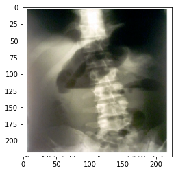

```python
# We see the corresponding caption along with the figure!

index = 0

with open("rojak_data.json", "r", encoding="utf-8", errors="surrogatepass") as file:
    dataset = json.load(file)

print("FIGURE PATH: ./scigraph_images/" + dataset[index]["img_file"])
print("CAPTION: " + dataset[index]["captions"][0])

im = cv2.imread("./scigraph_images/"+dataset[index]["img_file"])
plt.imshow(im)
plt.show()
```

We also can see the enriched concept identifiers/synsets we have discussed earlier, tied to their original word token in the following Pandas Dataframe!

```python
index = 0  #first figure

caption_token = dataset[index]["captions_tokens"][0]
caption_synset = dataset[index]["captions_synsets"][0]

tabl = [list(i) for i in zip(*[caption_token.split(" "), caption_synset.split(" ")])]

pd.DataFrame(tabl,columns=["tokens","synsets"])
```

|  | tokens | synsets |
| --- | --- | --- |
| 0 | abdominal | wn31_abdominal.a.01 |
| 1 | x-ray | wn31_x-ray.v.01 |
| 2 | revealing | wn31_bring+out.v.01 |
| 3 | several | wn31_respective.a.01 |
| 4 | air | wn31_air+out.v.01 |
| 5 | - | None |
| 6 | fluid | wn31_fluent.a.01 |
| 7 | levels | wn31_level.n.05 |
| 8 | of | None |
| 9 | the | None |
| 10 | small | wn31_small.a.01 |
| 11 | bowel | wn31_intestine.n.01 |
| 12 | and | None |
| 13 | a | None |
| 14 | large | wn31_large.a.01 |
| 15 | air | wn31_air+out.v.01 |
| 16 | - | None |
| 17 | fluid | wn31_fluent.a.01 |
| 18 | level | wn31_level.n.05 |
| 19 | of | None |
| 20 | the | None |
| 21 | sigmoid+colon | wn31_sigmoid+colon.n.01 |
| 22 | . | None |

### Model architecture

Please refer to Section 3.3 of our paper, where we explained the technical details of our model architecture in greater detail!

[figure not shown]

### Codebase for the normal baseline model

We standardise our evaluation test set, with the following seeded `train_test_split`

```python
_, test_indices = train_test_split(range(400), test_size=0.1, random_state=42)
```

```python
JSON_PATH = 'rojak_data.json'
RAW_TOKENIZER = './saved/tokenizers/normal_tokenizer_captions.pickle'
IMAGES_PATH = 'scigraph_images'

class Dataset:
    def __init__(self, json_path, image_path, tokenizer_path, maxLength):
        self.json_file = json_path
        self.image_path = image_path
        with open(tokenizer_path, 'rb') as handle:
            self.tokenizer = pickle.load(handle)
        self.tokensLength = maxLength
        self.raw_captions = []
        self.image_files = []
        self.proc_captions = []
        self.proc_images = []

    def generate_data(self):
        with open(self.json_file, 'r', encoding='utf-8', errors="surrogatepass") as file:
            dataset = json.load(file)
        for doc in tqdm(dataset): # edit later.
            self.raw_captions.extend(doc["captions"])
            self.image_files.append(os.path.join(self.image_path, doc["img_file"]))

    def _process_captions(self, token_seqs):
        # wrapping an additional list
        for seq in token_seqs:
            self.proc_captions.append([seq])

    def _process_image(self, image_file):
        f_img = open(image_file, 'rb')
        im = Image.open(f_img)
        im_arr = np.array(im.convert(mode='RGB'))
        im.close()
        f_img.close()
        return im_arr

    def process_data(self):
        sequences = self.tokenizer.texts_to_sequences(self.raw_captions)
        padded_sequences = pad_sequences(sequences, maxlen=self.tokensLength, padding="post", truncating="post")
        self._process_captions(padded_sequences)
        self.proc_images.extend([self._process_image(file) for file in tqdm(self.image_files, total=len(self.image_files))])


dataset = Dataset(JSON_PATH, IMAGES_PATH, RAW_TOKENIZER, 1000)
dataset.generate_data()
dataset.process_data()
```

```python
WEIGHTS_PATH = './saved/models/weak_fcc_model.h5' # we have provided the pretrained weights for our normal FCC baseline for evaluation!

class FCCModel:
    def __init__(self, dataset, weights_path, embedding_size):
        self.dataset = dataset
        self.weights_path = weights_path
        self.embedding_size = embedding_size

    def _get_model(self):
        modelImages = Sequential()
        modelImages.add(InputLayer(input_shape=(224,224,3)))
        modelImages.add(Conv2D(64, (3,3), padding = "same", activation="relu"))
        modelImages.add(BatchNormalization())
        modelImages.add(Conv2D(64, (3,3), padding = "same", activation="relu"))
        modelImages.add(BatchNormalization())
        modelImages.add(MaxPooling2D(2))
        modelImages.add(Conv2D(128, (3,3), padding = "same", activation="relu"))
        modelImages.add(BatchNormalization())
        modelImages.add(Conv2D(128, (3,3), padding = "same", activation="relu"))
        modelImages.add(BatchNormalization())
        modelImages.add(MaxPooling2D(2))
        modelImages.add(Conv2D(256, (3,3), padding = "same", activation="relu"))
        modelImages.add(BatchNormalization())
        modelImages.add(Conv2D(256, (3,3), padding = "same", activation="relu"))
        modelImages.add(BatchNormalization())
        modelImages.add(MaxPooling2D(2))
        modelImages.add(Conv2D(512, (3,3), padding = "same", activation="relu"))
        modelImages.add(BatchNormalization())
        modelImages.add(Conv2D(512, (3,3), padding = "same", activation="relu"))
        modelImages.add(BatchNormalization())
        modelImages.add(MaxPooling2D((28,28),2))

        modelCaptions = Sequential()
        modelCaptions.add(Embedding(len(self.dataset.tokenizer.word_index)+1, self.embedding_size, embeddings_initializer="uniform", input_length=self.dataset.tokensLength,trainable=True))
        modelCaptions.add(Conv1D(512, 5, activation="relu"))
        modelCaptions.add(MaxPooling1D(5))
        modelCaptions.add(Conv1D(512, 5, activation="relu"))
        modelCaptions.add(MaxPooling1D(5))
        modelCaptions.add(Conv1D(512, 5, activation="relu"))
        modelCaptions.add(MaxPooling1D(35))
        modelCaptions.add(Reshape((1, 1, 512)))

        mergedOut = Multiply()([modelCaptions.output,modelImages.output])
        mergedOut = Flatten()(mergedOut)
        mergedOut = Dense(128, activation='relu')(mergedOut)
        mergedOut = Dense(2, activation='softmax')(mergedOut)
        model = Model([modelCaptions.input,modelImages.input], mergedOut)

        if self.weights_path:
            model.load_weights(self.weights_path)

        return model

    def _generate_eval_data(self, indexes):
        np.random.seed(42)

        tuples_to_shuffle = []
        for idx in indexes:
            tuple1 = []
            tuple1_minilist = []
            tuple1_minilist.append(self.dataset.proc_captions[idx][0])
            tuple1_minilist.append(self.dataset.proc_images[idx])
            tuple1.append(tuple1_minilist)
            tuple1.append(np.array([0,1]))
            tuples_to_shuffle.append(tuple1)

            rand_ind = random.choice([x for x in range(len(self.dataset.proc_images)) if x != idx])
            tuple2 = []
            tuple2_minilist = []
            tuple2_minilist.append(self.dataset.proc_captions[rand_ind][0])
            tuple2_minilist.append(self.dataset.proc_images[idx])
            tuple2.append(tuple2_minilist)
            tuple2.append(np.array([1,0]))
            tuples_to_shuffle.append(tuple2)

        random.shuffle(tuples_to_shuffle)
        bx = [[],[]]
        y = []
        for i in tuples_to_shuffle:
            for k in range(len(i[0])):
                bx[k].append(i[0][k])
            y.append(i[1])

        X = [np.array(x) for x in bx]

        return X, np.array(y)

    def evaluate(self):
        model = self._get_model()
        adam = Adam(lr=1e-4,decay=1e-5)
        model.compile(loss="categorical_crossentropy", optimizer=adam, metrics=["categorical_accuracy"])
        indices = list(range(len(self.dataset.proc_images)))
        X_eval, y_eval = self._generate_eval_data(indices)
        model.evaluate(X_eval, y_eval, batch_size=16, verbose=1, workers=-1)

    def predict(self):
        model = self._get_model()
        indices = list(range(len(self.dataset.proc_images)))
        X_eval, y_eval = self._generate_eval_data(indices)
#         prediction for one single example
#         test = [np.array([X_eval[0][0]]), np.array([X_eval[1][0]])]
#         predictions = model.predict(test)
        predictions = model.predict(X_eval, batch_size=32, verbose=1, workers=-1)
        return predictions

    def image_retrieval_task(self, indices):
        model = self._get_model()
        r_at_1 = 0
        r_at_5 = 0
        r_at_10 = 0

        for i in tqdm(indices, total=len(indices)):
            bx = []
            bx.append(np.expand_dims(self.dataset.proc_captions[i][0],axis=0))
            bx.append(np.expand_dims(self.dataset.proc_images[i],axis=0))

            count_cand = 0
            good_pred = model.predict(bx)
            for j in indices:
                if i == j:
                    continue
                else:
                    bx[-1] = np.expand_dims(self.dataset.proc_images[j], axis=0)
                cand_pred = model.predict(bx)
                if cand_pred[:,1] > good_pred[:,1]:
                    count_cand = count_cand + 1
                if count_cand >= 10:
                    break
            if count_cand < 1:
                r_at_1 += 1
            if count_cand < 5:
                r_at_5 += 1
            if count_cand < 10:
                r_at_10 += 1
        print("IMAGE RETRIEVAL (r@1: {} r@5: {} r@10: {}".format(r_at_1/(len(indices)), r_at_5/(len(indices)), r_at_10/(len(indices))))

    def caption_retrieval_task(self, indices):
        model = self._get_model()
        r_at_1 = 0
        r_at_5 = 0
        r_at_10 = 0

        for i in tqdm(indices, total=len(indices)):
            good_preds = []
            bx = []
            bx.append(np.expand_dims(self.dataset.proc_captions[i][0],axis=0))
            bx.append(np.expand_dims(self.dataset.proc_images[i],axis=0))
            good_preds.append(model.predict(bx))

            good_pred = good_preds[np.argmax([x[:,1] for x in good_preds])]
            count_cand = 0

            for j in indices:
                if i == j:
                    continue
                bx = []
                bx.append(np.expand_dims(self.dataset.proc_captions[j][0],axis=0))
                bx.append(np.expand_dims(self.dataset.proc_images[i],axis=0))
                cand_pred = model.predict(bx)
                if cand_pred[:,1] > good_pred[:,1]:
                    count_cand += 1

                if count_cand >= 10:
                    break
            if count_cand < 1:
                r_at_1 += 1
            if count_cand < 5:
                r_at_5 += 1
            if count_cand < 10:
                r_at_10 += 1
        print("CAPTION RETRIEVAL (r@1: {} r@5: {} r@10: {}".format(r_at_1/(len(indices)), r_at_5/(len(indices)), r_at_10/(len(indices))))
```

```python
normalFCC = FCCModel(dataset, WEIGHTS_PATH, 300)
```

```python
normalFCC.evaluate()
```

[output not shown]

```python
_, test_indices = train_test_split(range(400), test_size=0.1, random_state=42)
```

```python
normalFCC.image_retrieval_task(test_indices)
```

```
IMAGE RETRIEVAL (r@1: 0.175 r@5: 0.475 r@10: 0.8
```

```python
normalFCC.caption_retrieval_task(test_indices)
```

```
CAPTION RETRIEVAL (r@1: 0.125 r@5: 0.5 r@10: 0.85
```

### Codebase for the ROJAK model

```python
JSON_PATH = 'rojak_data.json'
ROJAK_TOKENIZER = './saved/tokenizers/rojak_tokenizer_captions.pickle'
ROJAK_SYNSET_TOKENIZER = './saved/tokenizers/rojak_tokenizer_synsets.pickle'
IMAGES_PATH = 'scigraph_images'

class RojakDataset:
    def __init__(self, json_path, image_path, caption_tokenizer, synset_tokenizer, maxLength):
        self.json_file = json_path
        self.image_path = image_path
        with open(caption_tokenizer, 'rb') as handle:
            self.caption_tokenizer = pickle.load(handle)
        with open(synset_tokenizer, 'rb') as handle:
            self.synset_tokenizer = pickle.load(handle)
        self.tokensLength = maxLength
        self.raw_captions = []
        self.raw_synsets = []
        self.image_files = []
        self.proc_captions = []
        self.proc_synsets = []
        self.proc_images = []

    def generate_data(self):
        with open(self.json_file, 'r', encoding='utf-8', errors="surrogatepass") as file:
            dataset = json.load(file)
        for doc in tqdm(dataset): # edit later.
            self.raw_captions.extend(doc["captions_tokens"])
            self.raw_synsets.extend(doc["captions_synsets"])
            self.image_files.append(os.path.join(self.image_path, doc["img_file"]))

#     def _process_captions(self, token_seqs):
#         # wrapping an additional list
#         for seq in token_seqs:
#             self.proc_captions.append([seq])

    def _process_image(self, image_file):
        f_img = open(image_file, 'rb')
        im = Image.open(f_img)
        im_arr = np.array(im.convert(mode='RGB'))
        im.close()
        f_img.close()
        return im_arr

    def process_data(self):
        caption_sequences = self.caption_tokenizer.texts_to_sequences(self.raw_captions)
        synset_sequences = self.synset_tokenizer.texts_to_sequences(self.raw_synsets)

        self.proc_captions = pad_sequences(caption_sequences, maxlen=self.tokensLength, padding="post", truncating="post")
        self.proc_synsets = pad_sequences(synset_sequences, maxlen=self.tokensLength, padding="post", truncating="post")
        self.proc_images.extend([self._process_image(file) for file in tqdm(self.image_files, total=len(self.image_files))])


rojak_dataset = RojakDataset(JSON_PATH, IMAGES_PATH, ROJAK_TOKENIZER, ROJAK_SYNSET_TOKENIZER, 1000)
rojak_dataset.generate_data()
rojak_dataset.process_data()

# print(rojak_dataset.proc_synsets.shape)
# print(rojak_dataset.proc_captions.shape)
# len(rojak_dataset.synset_tokenizer.word_index)
```

```python
ROJAK_WEIGHTS_PATH = './saved/models/rojak_fcc_model.h5'
ROJAK_EMB_PATH = 'scigraph_wordnet.tsv'

class RojakFCCModel:
    def __init__(self, dataset, weights_path, kg_embedding_path, token_embedding_size):
        self.dataset = dataset
        self.weights_path = weights_path
        self.kg_token_embeddings = {}
        self.kg_synset_embeddings = {}
        self.token_embedding_size = token_embedding_size

        with open(kg_embedding_path, 'r', encoding="utf-8", errors="surrogatepass") as f:
             for line in f:
                values = line.split()
                comp_len = len(values) - self.token_embedding_size
                word = "+".join(values[0:comp_len])
                if (line.startswith("wn31")):
                    vector = np.asarray(values[comp_len:], dtype='float32')
                    self.kg_synset_embeddings[word] = vector
                else:
                    if (line.startswith("grammar#")):
                        continue
                    else:
                        vector = np.asarray(values[comp_len:], dtype='float32')
                        self.kg_token_embeddings[word] = vector

    def _get_model(self):
        self.token_emb_mat = np.zeros((len(self.dataset.caption_tokenizer.word_index)+1, self.token_embedding_size))
        for word, i in self.dataset.caption_tokenizer.word_index.items():
            emb_vec = self.kg_token_embeddings.get(word)
            if emb_vec is not None:
                self.token_emb_mat[i] = emb_vec

        self.synset_emb_mat = np.zeros((len(self.dataset.synset_tokenizer.word_index)+1, self.token_embedding_size))
        for word, i in self.dataset.synset_tokenizer.word_index.items():
            syn_emb_vec = self.kg_synset_embeddings.get(word)
            if syn_emb_vec is not None:
                self.synset_emb_mat[i] = syn_emb_vec

        # Model Architecture

        modelFigures = Sequential()
        modelFigures.add(InputLayer(input_shape=(224,224,3)))
        modelFigures.add(Conv2D(64, (3,3), padding = "same", activation="relu"))
        modelFigures.add(BatchNormalization())
        modelFigures.add(Conv2D(64, (3,3), padding = "same", activation="relu"))
        modelFigures.add(BatchNormalization())
        modelFigures.add(MaxPooling2D(2))
        modelFigures.add(Conv2D(128, (3,3), padding = "same", activation="relu"))
        modelFigures.add(BatchNormalization())
        modelFigures.add(Conv2D(128, (3,3), padding = "same", activation="relu"))
        modelFigures.add(BatchNormalization())
        modelFigures.add(MaxPooling2D(2))
        modelFigures.add(Conv2D(256, (3,3), padding = "same", activation="relu"))
        modelFigures.add(BatchNormalization())
        modelFigures.add(Conv2D(256, (3,3), padding = "same", activation="relu"))
        modelFigures.add(BatchNormalization())
        modelFigures.add(MaxPooling2D(2))
        modelFigures.add(Conv2D(512, (3,3), padding = "same", activation="relu"))
        modelFigures.add(BatchNormalization())
        modelFigures.add(Conv2D(512, (3,3), padding = "same", activation="relu"))
        modelFigures.add(BatchNormalization())
        modelFigures.add(MaxPooling2D((28,28),2))
        modelFigures.add(Flatten())

        modelCaptionsScratch = Sequential()
        modelCaptionsScratch.add(Embedding(len(self.dataset.caption_tokenizer.word_index)+1, self.token_embedding_size, embeddings_initializer="uniform", input_length=self.dataset.tokensLength, trainable=True))
        modelCaptionsVecsiTokens = Sequential()
        modelCaptionsVecsiTokens.add(Embedding(len(self.dataset.caption_tokenizer.word_index) + 1, self.token_embedding_size, weights = [self.token_emb_mat], input_length=self.dataset.tokensLength, trainable=False))
        modelCaptionsVecsiSynsets = Sequential()
        modelCaptionsVecsiSynsets.add(Embedding(len(self.dataset.synset_tokenizer.word_index) + 1, self.token_embedding_size, weights = [self.synset_emb_mat], input_length=self.dataset.tokensLength, trainable=False))
        modelMergeEmbeddings = Concatenate()([modelCaptionsScratch.output,modelCaptionsVecsiTokens.output,modelCaptionsVecsiSynsets.output])
        modelMergeEmbeddings = Conv1D(512, 5, activation="relu")(modelMergeEmbeddings)
        modelMergeEmbeddings = MaxPooling1D(5)(modelMergeEmbeddings)
        modelMergeEmbeddings = Conv1D(512, 5, activation="relu")(modelMergeEmbeddings)
        modelMergeEmbeddings = MaxPooling1D(5)(modelMergeEmbeddings)
        modelMergeEmbeddings = Conv1D(512, 5, activation="relu")(modelMergeEmbeddings)
        modelMergeEmbeddings = MaxPooling1D(35)(modelMergeEmbeddings)
        modelMergeEmbeddings = Flatten()(modelMergeEmbeddings)
        modelCaptions = Model([modelCaptionsScratch.input,modelCaptionsVecsiTokens.input,modelCaptionsVecsiSynsets.input], modelMergeEmbeddings)

        mergedOut = Multiply()([modelCaptions.output,modelFigures.output])
        mergedOut = Dense(128, activation='relu')(mergedOut)
        mergedOut = Dense(2, activation='softmax')(mergedOut)
        rojak_model = Model([modelCaptionsScratch.input,modelCaptionsVecsiTokens.input,modelCaptionsVecsiSynsets.input, modelFigures.input], mergedOut)

        if self.weights_path:
            rojak_model.load_weights(self.weights_path)

        return rojak_model

    def _generate_eval_data(self, indexes):

        tuples_to_shuffle = []
        for idx in indexes:
            tuple1 = []
            tuple1.append(self.dataset.proc_captions[idx])
            tuple1.append(self.dataset.proc_captions[idx])
            tuple1.append(self.dataset.proc_synsets[idx])
            tuple1.append(self.dataset.proc_images[idx])
            tuple1.append(np.array([0,1]))
            tuples_to_shuffle.append(tuple1)

            rand_ind = random.choice([x for x in range(len(self.dataset.proc_images)) if x != idx])
            tuple2 = []
            tuple2.append(self.dataset.proc_captions[rand_ind])
            tuple2.append(self.dataset.proc_captions[rand_ind])
            tuple2.append(self.dataset.proc_synsets[rand_ind])
            tuple2.append(self.dataset.proc_images[idx])
            tuple2.append(np.array([1,0]))
            tuples_to_shuffle.append(tuple2)

        np.random.seed(42)
        random.shuffle(tuples_to_shuffle)

        bx0, bx1, bx2, bx3, y = [], [], [], [], []

        for tup in tuples_to_shuffle:
            bx0.append(tup[0])
            bx1.append(tup[1])
            bx2.append(tup[2])
            bx3.append(tup[3])
            y.append(tup[4])

        X = [np.array(bx0),np.array(bx1),np.array(bx2),np.array(bx3)]

        return X, np.array(y)

    def evaluate(self):
        model = self._get_model()
        adam = Adam(lr=1e-4,decay=1e-5)
        model.compile(loss="categorical_crossentropy", optimizer=adam, metrics=["categorical_accuracy"])
        indices = list(range(len(self.dataset.proc_images)))
        print(f'Evaluating on {len(indices)} samples')
        X_eval, y_eval = self._generate_eval_data(indices)
        model.evaluate(X_eval, y_eval, batch_size=32, verbose=1, workers=-1)


    def predict(self):
        model = self._get_model()
        indices = list(range(len(self.dataset.proc_images)))
        X_eval, y_eval = self._generate_eval_data(indices)
        predictions = model.predict(X_eval, batch_size=8, verbose=1, workers=-1)
        return predictions

    def image_retrieval_task(self, indices):
        model = self._get_model()
        r_at_1 = 0
        r_at_5 = 0
        r_at_10 = 0

        for i in tqdm(indices, total=len(indices)):
            bx = []
            bx.append(np.expand_dims(self.dataset.proc_captions[i],axis=0))
            bx.append(np.expand_dims(self.dataset.proc_captions[i],axis=0))
            bx.append(np.expand_dims(self.dataset.proc_synsets[i],axis=0))
            bx.append(np.expand_dims(self.dataset.proc_images[i],axis=0))

            count_cand = 0
            good_pred = model.predict(bx)
            for j in indices:
                if i == j:
                    continue
                bx[-1] = np.expand_dims(self.dataset.proc_images[j], axis=0)
                cand_pred = model.predict(bx)
                if cand_pred[:,1] > good_pred[:,1]:
                    count_cand = count_cand + 1
                if count_cand >= 10:
                    break
            if count_cand < 1:
                r_at_1 += 1
            if count_cand < 5:
                r_at_5 += 1
            if count_cand < 10:
                r_at_10 += 1
        print("IMAGE RETRIEVAL (r@1: {} r@5: {} r@10: {}".format(r_at_1/(len(indices)), r_at_5/(len(indices)), r_at_10/(len(indices))))

    def caption_retrieval_task(self, indices):
        model = self._get_model()
        r_at_1 = 0
        r_at_5 = 0
        r_at_10 = 0

        for i in tqdm(indices, total=len(indices)):
            bx = []
            bx.append(np.expand_dims(self.dataset.proc_captions[i],axis=0))
            bx.append(np.expand_dims(self.dataset.proc_captions[i],axis=0))
            bx.append(np.expand_dims(self.dataset.proc_synsets[i],axis=0))
            bx.append(np.expand_dims(self.dataset.proc_images[i],axis=0))

            count_cand = 0
            good_pred = model.predict(bx)
            for j in indices:
                if i == j:
                    continue
                bx[0] = np.expand_dims(self.dataset.proc_captions[j],axis=0)
                bx[1] = np.expand_dims(self.dataset.proc_captions[j],axis=0)
                bx[2] = np.expand_dims(self.dataset.proc_synsets[j],axis=0)
                cand_pred = model.predict(bx)
                if cand_pred[:,1] > good_pred[:,1]:
                    count_cand = count_cand + 1
                if count_cand >= 10:
                    break
            if count_cand < 1:
                r_at_1 += 1
            if count_cand < 5:
                r_at_5 += 1
            if count_cand < 10:
                r_at_10 += 1

        print("CAPTION RETRIEVAL (r@1: {} r@5: {} r@10: {}".format(r_at_1/(len(indices)), r_at_5/(len(indices)), r_at_10/(len(indices))))
```

```python
rojakFCC = RojakFCCModel(rojak_dataset, ROJAK_WEIGHTS_PATH, ROJAK_EMB_PATH, 100)
```

```python
rojakFCC.evaluate()
```

[output not shown]

```python
rojakFCC.image_retrieval_task(test_indices)
```

```
IMAGE RETRIEVAL (r@1: 0.2 r@5: 0.6 r@10: 0.7
```

```python
rojakFCC.caption_retrieval_task(test_indices)
```

```
CAPTION RETRIEVAL (r@1: 0.2 r@5: 0.525 r@10: 0.725
```